## Red Knot DFA Simplified Summary

This is a brief summary of the DFA conducted on roselaari Red Knots. The purpose of this work is to determine a formula to be used in the field to sex birds for satellite attachement purposes.

### Sample Size

We have 86 molecularly sexed birds from Nome and 103 molecularly sexed birds from Grays Harbor that have the four core measurements – diagonal tarsus, wing, total head, and culmen. We have a male bias sample from both Nome, AK (81.4% male) and Grays Harbor, WA (56.3% male). The extremely bias ratio in Nome is due to our capture techniques targeting brood rearing birds in recent years.

### Male-Female Sexual Size Dimorphism

As expected, females were significantly larger in three out of four of our measurements. Females were significantly larger in total head (*P*<.001), culmen (*P*<.001), and wing (*P*<.001), but not significantly larger in diagonal tarsus (*P*=.12).

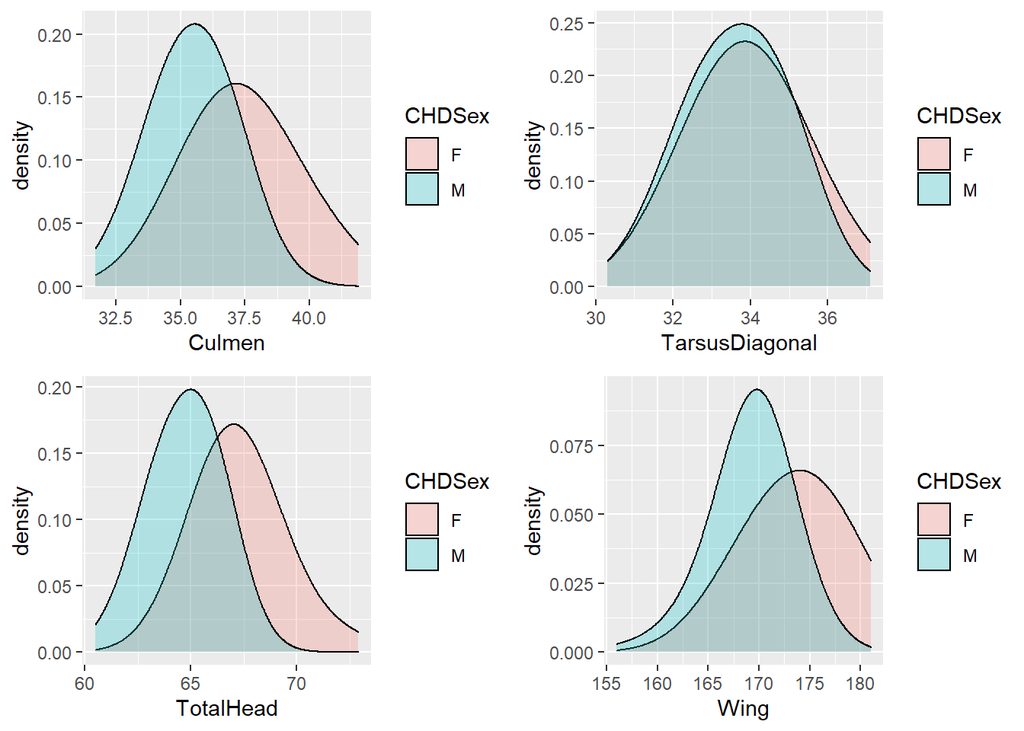

Figure 2. Density plots of each sexes measurements. Culmen, total head, and wing are the only measurments that showed significant difference between the two sexes.

### Using DFA to guide field sexing

Using a automated stepwise approach, total head and wing were selected as the best variables to accurately sex birds.

```
## correctness rate: 0.8254;  in: "TotalHead";  variables (1): TotalHead
## correctness rate: 0.84656;  in: "Wing";  variables (2): TotalHead, Wing
##
##  hr.elapsed min.elapsed sec.elapsed
##        0.00        0.00        3.61
```

```
## method      : lda
## final model : CHDSex ~ TotalHead + Wing
## <environment: 0x000000001a9e2478>
##
## correctness rate = 0.8466
```

A cross-validated review of all biologically relevant variables while omitting highly correlated variables (total head and culmen, r=0.86) in the same model, resulted in total head, wing, and tarsus predicting sex with the highest accuracy. The two-variable model (total head and wing) selected by the automated approach was a very close second, and is more meaningful given the lack of separation between males and females in diagonal tarsus. Moving forward, we will use the total head and wing model.

```r
library(MASS)

#lda using all variables
jacknife1 <- lda(CHDSex~.,data = all.rekn.outliers.out, CV = TRUE)
#lda using culmen, wing, and tarsus
jacknife2 <- lda(CHDSex~ Culmen + Wing + TarsusDiagonal, data = all.rekn.outliers.out, CV = TRUE)
#lda using culmen, wing, and total head
jacknife3 <- lda(CHDSex~ TotalHead + Wing + TarsusDiagonal, data = all.rekn.outliers.out, CV = TRUE)
#lda using total head and wing
jacknife4 <- lda(CHDSex~ TotalHead + Wing, data = all.rekn.outliers.out, CV = TRUE)
#lda using culmen and wing
jacknife5 <- lda(CHDSex~ Culmen + Wing, data = all.rekn.outliers.out, CV = TRUE)
```

Model output for total head, wing, and tarsus. Note the accuracy is very similar to total head and wing. Tarsus did not do much to imporve the model, and any improvements could have been due to random chance.

```
## Confusion Matrix and Statistics
##
##             Predicted Group
## Actual Group   F   M
##            F  42  19
##            M   9 118
##
##                Accuracy : 0.8511
##                  95% CI : (0.792, 0.8987)
##     No Information Rate : 0.7287
##     P-Value [Acc > NIR] : 4.786e-05
##
##                   Kappa : 0.6451
##
##  Mcnemar's Test P-Value : 0.08897
##
##             Sensitivity : 0.8235
##             Specificity : 0.8613
##          Pos Pred Value : 0.6885
##          Neg Pred Value : 0.9291
##              Prevalence : 0.2713
##          Detection Rate : 0.2234
##    Detection Prevalence : 0.3245
##       Balanced Accuracy : 0.8424
##
##        'Positive' Class : F
##
```

Model output for total head and wing. Note this model’s accuracy is very similar to total head, wing, and tarus.

```
## Confusion Matrix and Statistics
##
##             Predicted Group
## Actual Group   F   M
##            F  42  19
##            M  10 117
##
##                Accuracy : 0.8457
##                  95% CI : (0.786, 0.8942)
##     No Information Rate : 0.7234
##     P-Value [Acc > NIR] : 5.452e-05
##
##                   Kappa : 0.6341
##
##  Mcnemar's Test P-Value : 0.1374
##
##             Sensitivity : 0.8077
##             Specificity : 0.8603
##          Pos Pred Value : 0.6885
##          Neg Pred Value : 0.9213
##              Prevalence : 0.2766
##          Detection Rate : 0.2234
##    Detection Prevalence : 0.3245
##       Balanced Accuracy : 0.8340
##
##        'Positive' Class : F
##
```

```
##             Predicted Group
## Actual Group   F   M
##            F  42  19
##            M  10 117
```

This resulted in accurately classifying 84.57% of individuals with 95% CI (78.6%, 89.42%)

### Equation for field sexing

Using the total head and wing model, we can extract the coefficients to create an equation for field sexing an individual.

```r
#run the lda with Total Head, Wing, and Tarsus as variables
lda4 <- lda(CHDSex~ TotalHead + Wing, data = all.rekn.outliers.out)

lda4
```

```
## Call:
## lda(CHDSex ~ TotalHead + Wing, data = all.rekn.outliers.out)
##
## Prior probabilities of groups:
##         F         M
## 0.3244681 0.6755319
##
## Group means:
##   TotalHead     Wing
## F  67.31803 173.6393
## M  64.72362 169.2449
##
## Coefficients of linear discriminants:
##                  LD1
## TotalHead -0.4974653
## Wing      -0.1001247
```

$-0.1001247 Wing - 0.4974653 Total Head = LD1$

```r
predict4 <- predict(lda4, newdata = all.rekn.outliers.out)

predict4.df <- data.frame(type = all.rekn.outliers.out[,1], lda = predict4$x)
```

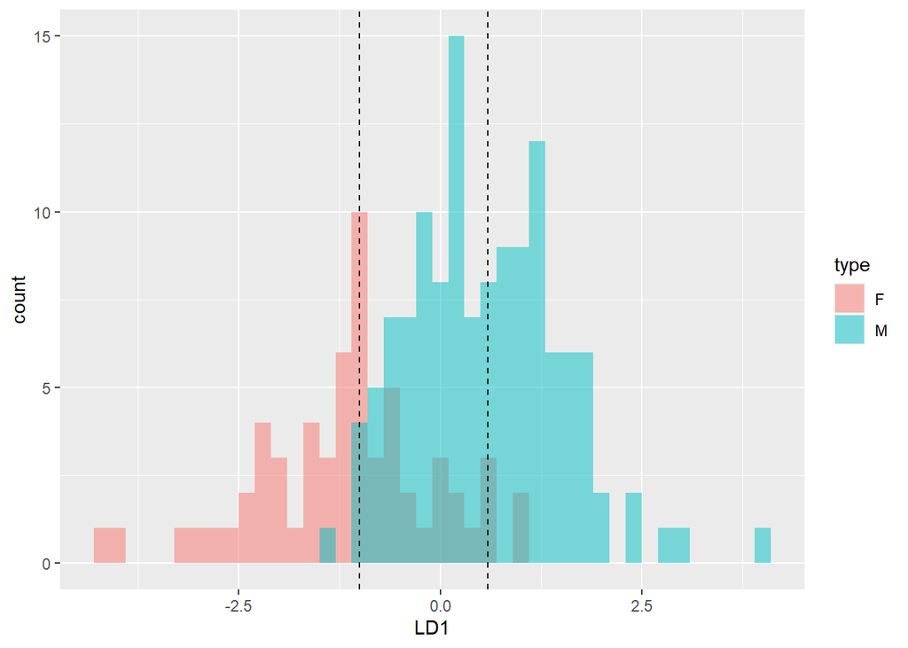